# Heat Load Analysis

```r
  RG_inspect_data (Dat.rs.w,
                   Var_list_input=c("Temperature","Power"),
                   week_list_input=c(),
                   month_list_input=c()
  )
```

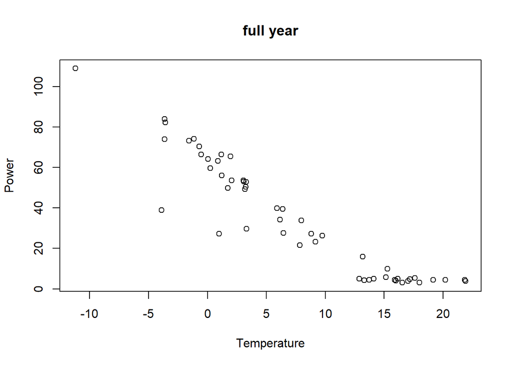

```r
  RG_inspect_data (Dat.rs.m,
                   Var_list_input=c("Temperature","Power"),
                   week_list_input=c(),
                   month_list_input=c()
  )
```

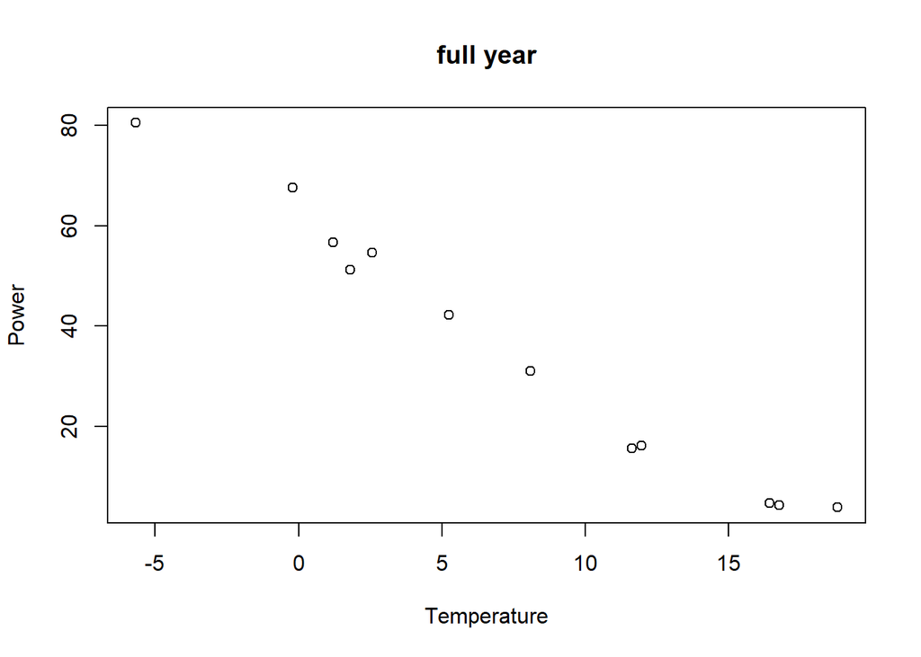

## Insight

Daily periods vary due to a set of facts/schedules (building dependent) weekly occupation pattern

Weekly data allows to see the main trends (except for intra-daily & inter-daily issues) There is a minimum heat load during the hot/summer months There is a linear heat load vs temperature period in the cold/winter months There is an intermediate period in mild/spring/autumn months

ONLY ONE linear dependency against temperature can be seen (as opposed to the information with daily data)

Monthly data provides ~the same information as weekly data, but with fewer points.

# Initial Changepoint model and outlier detection

A model is trained for the dataset. It consist of a changepoint model segmented for each hour of the week (168 models) Then the observations too far from the model are discarded. This process takes in the range of 3 minutes.

## Inspection of the changepoint model

Before discarding of outliers

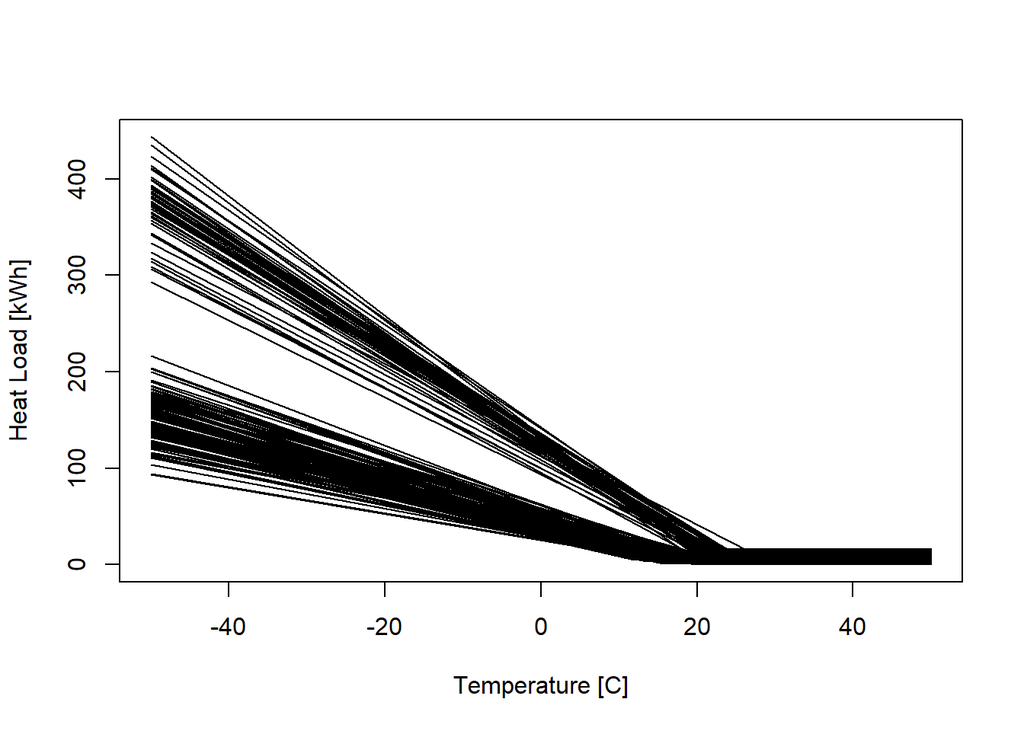

```r
Changepoint_plot_coordinates<-Changepoint_Parameters_summary

Changepoint_plot_coordinates$x1<- -50
Changepoint_plot_coordinates$y1<- Changepoint_plot_coordinates$intercept+Changepoint_plot_coordinates$slope_Temp*Changepoint_plot_coordinates$x1

Changepoint_plot_coordinates$x2<- -(Changepoint_plot_coordinates$intercept-Changepoint_plot_coordinates$minimum)/Changepoint_plot_coordinates$slope_Temp
Changepoint_plot_coordinates$y2<-  Changepoint_plot_coordinates$minimum

Changepoint_plot_coordinates$x3<-  50
Changepoint_plot_coordinates$y3<-  Changepoint_plot_coordinates$minimum

plot(c(-50,50),c(0,max (Changepoint_plot_coordinates$y1)),
     type="n",
     xlab="Temperature [C]",
     ylab="Heat Load [kWh]")

for (ni in Changepoint_plot_coordinates$DATE_hour_week)
{
  bool<-Changepoint_plot_coordinates$DATE_hour_week==ni
  varX<-c(Changepoint_plot_coordinates$x1[bool],Changepoint_plot_coordinates$x2[bool],Changepoint_plot_coordinates$x3[bool])
  varY<-c(Changepoint_plot_coordinates$y1[bool],Changepoint_plot_coordinates$y2[bool],Changepoint_plot_coordinates$y3[bool])

  lines (varX,varY)
}
```

```r
rm(Changepoint_plot_coordinates, ni, varX, varY, bool)
```

## Insight

Overall, the same two main patterns are identified, with some specificities for each hour.

It seems that for some specific hours, a third pattern can be observed. Without heat loads for loads above ~0ºC. (This only happens sometimes, based on the genetic algorithm identification process).

```r
# save.image(paste(WD,"Workspace.RData",sep="/"))
#
# WD<-getwd()
# load(paste(WD,"Workspace.RData",sep="/"))
```

# Repair dataset

The current dataset only contains observations for those timestamps where an original observation was available in the dataset. This chunk of code generates an empty observation for every hour in between the initial and final timestamps.

The content of the observations is also updated as follows:

- IS_Outlier: TRUE/FALSE/CORRECTED (only energy is corrected)
- IS_Missing: TRUE/FALSE/CORRECTED (both energy and climate are corrected)
- Power_Corrected

Corrections are performed stepwise.

## Interpolation

<1h voids, with data available for the -1 .. 1h slot on the previous and following weeks.

<5h voids, with data available for the -5 .. 5h slot on the previous and following weeks. This is done stepwise. First 2h voids, then 3h voids,…

## Insight

In the range of 5% of data is identified as outliers. The data filling process are able to reconstruct 30% of the outlier data. This is mostly achieved through the 1h void filling process.

# Recalculate changepoint

Once outliers are discarded and data is (partially) repaired. This process takes in the range of 3 minutes.

## Inspection of the changepoint model

After discarding of outliers

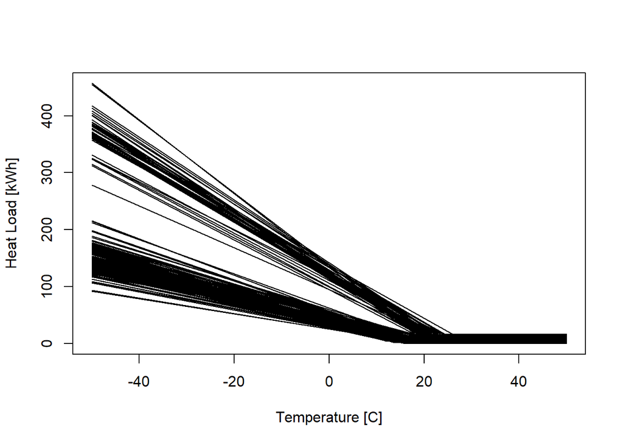

```r
Changepoint_plot_coordinates<-Changepoint_Parameters_summary_v2

Changepoint_plot_coordinates$x1<- -50
Changepoint_plot_coordinates$y1<- Changepoint_plot_coordinates$intercept+Changepoint_plot_coordinates$slope_Temp*Changepoint_plot_coordinates$x1

Changepoint_plot_coordinates$x2<- -(Changepoint_plot_coordinates$intercept-Changepoint_plot_coordinates$minimum)/Changepoint_plot_coordinates$slope_Temp
Changepoint_plot_coordinates$y2<-  Changepoint_plot_coordinates$minimum

Changepoint_plot_coordinates$x3<-  50
Changepoint_plot_coordinates$y3<-  Changepoint_plot_coordinates$minimum

plot(c(-50,50),c(0,max (Changepoint_plot_coordinates$y1)),
     type="n",
     xlab="Temperature [C]",
     ylab="Heat Load [kWh]")

for (ni in Changepoint_plot_coordinates$DATE_hour_week)
{
  bool<-Changepoint_plot_coordinates$DATE_hour_week==ni
  varX<-c(Changepoint_plot_coordinates$x1[bool],Changepoint_plot_coordinates$x2[bool],Changepoint_plot_coordinates$x3[bool])
  varY<-c(Changepoint_plot_coordinates$y1[bool],Changepoint_plot_coordinates$y2[bool],Changepoint_plot_coordinates$y3[bool])

  lines (varX,varY)
}
```

```r
rm(Changepoint_plot_coordinates, ni, varX, varY)
```

```r
save.image(paste(WD,"Workspace.RData",sep="/"))

WD<-getwd()
load(paste(WD,"Workspace.RData",sep="/"))
```

# Model statistics

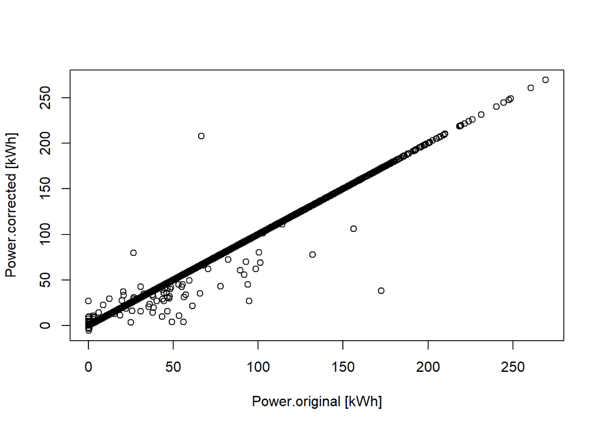

```r
num_outliers<-sum(Dat1$IS_Outlier)
prop_outliers<-num_outliers/dim(Dat1)[1]

num_repaired_1<-sum(Dat2$IS_Repaired)
prop_repaired_1<-num_repaired_1/num_outliers

num_repaired_2<-sum(Dat3$IS_Repaired)
prop_repaired_2<-num_repaired_2/num_outliers

plot(Dat3$Power,Dat3$Power_corrected,
     xlab="Power.original [kWh]", ylab="Power.corrected [kWh]")
```

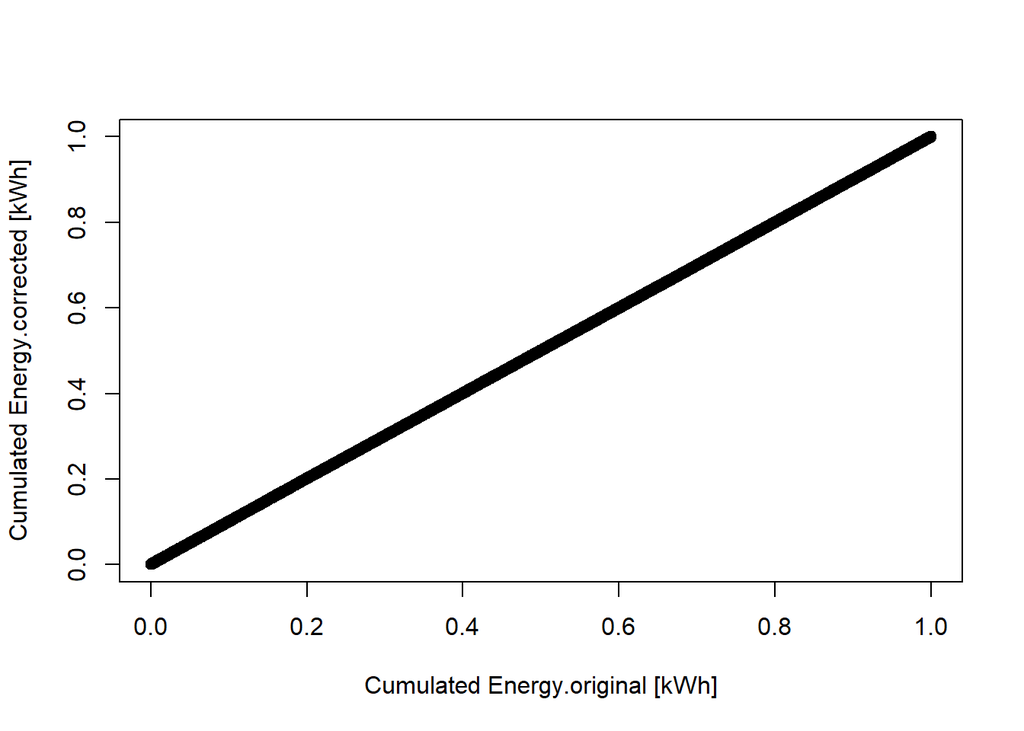

```r
plot(cumsum(Dat2$Power)/sum(Dat2$Power),
     cumsum(Dat2$Power_corrected)/sum(Dat2$Power_corrected),
     xlab="Cumulated Energy.original [kWh]", ylab="Cumulated Energy.corrected [kWh]")
```

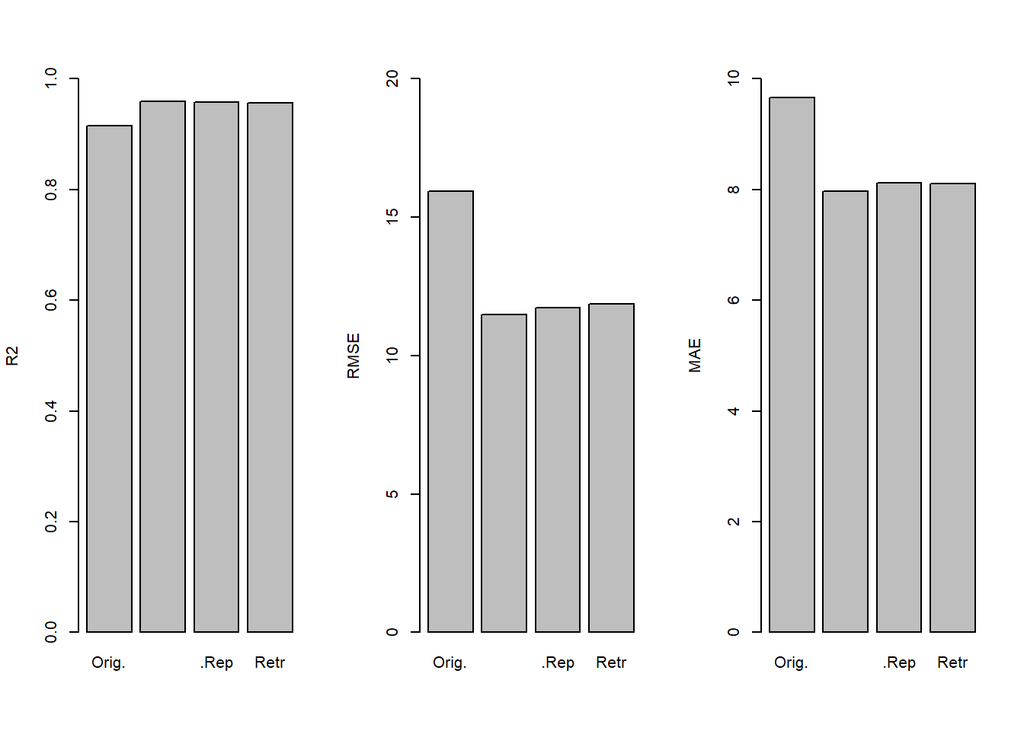

```r
Power_orig<-sum(Dat3$Power)
Power_corrected<-sum(Dat3$Power_corrected)
Power_correction<-(Power_corrected-Power_orig)/Power_orig

R2_orig<-cor(Dat1$Power_fitted,Dat1$Power)
RMSE_orig<-rmse(Dat1$Power_fitted,Dat1$Power)
MAE_orig<-mae(Dat1$Power_fitted,Dat1$Power)
Power_orig_by_hour<-aggregate(Power ~ DATE_hour_day, data=Dat1, mean)[,2]

Dat1_no_outlier<-Dat1[!Dat1$IS_Outlier,]
R2_no_outlier<-cor(Dat1_no_outlier$Power_fitted,Dat1_no_outlier$Power)
RMSE_no_outlier<-rmse(Dat1_no_outlier$Power_fitted,Dat1_no_outlier$Power)
MAE_no_outlier<-mae(Dat1_no_outlier$Power_fitted,Dat1_no_outlier$Power)
Power_no_outlier_by_hour<-aggregate(Power ~ DATE_hour_day, data=Dat1_no_outlier, mean)[,2]

Dat3_repaired<-Dat3[!Dat3$IS_Outlier-Dat3$IS_Repaired,]
R2_repaired<-cor(Dat3_repaired$Power_fitted,Dat3_repaired$Power_corrected)
RMSE_repaired<-rmse(Dat3_repaired$Power_fitted,Dat3_repaired$Power_corrected)
MAE_repaired<-mae(Dat3_repaired$Power_fitted,Dat3_repaired$Power_corrected)
Power_repaired_by_hour<-aggregate(Power_corrected ~ DATE_hour_day, data=Dat3_repaired, mean)[,2]

Dat4_no_outlier<-Dat1[!Dat4$IS_Outlier,]
R2_repaired_retrained<-cor(Dat4_no_outlier$Power_fitted,Dat4_no_outlier$Power)
RMSE_repaired_retrained<-rmse(Dat4_no_outlier$Power_fitted,Dat4_no_outlier$Power)
MAE_repaired_retrained<-mae(Dat4_no_outlier$Power_fitted,Dat4_no_outlier$Power)
Power_repaired_retrained_by_hour<-aggregate(Power ~ DATE_hour_day, data=Dat4_no_outlier, mean)[,2]


R2<-c(R2_orig, R2_no_outlier, R2_repaired, R2_repaired_retrained)
RMSE<-c(RMSE_orig, RMSE_no_outlier, RMSE_repaired, RMSE_repaired_retrained)
MAE<-c(MAE_orig, MAE_no_outlier, MAE_repaired, MAE_repaired_retrained)

legend <- c("Orig.", "Out.Rm", ".Rep", "Retr")

par(mfrow=c(1,3))
barplot(R2,     ylim=c(0,1),     names.arg=legend,     ylab="R2")
barplot(RMSE,   ylim=c(0,20),    names.arg=legend,     ylab="RMSE")
barplot(MAE,    ylim=c(0,10),    names.arg=legend,     ylab="MAE")
```

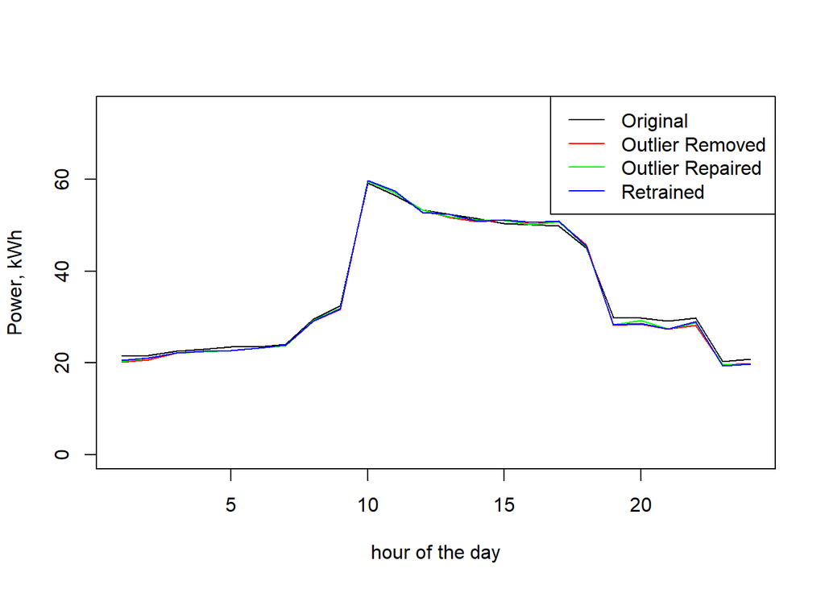

```r
par(mfrow=c(1,1))

legend<- c("Original", "Outlier Removed", "Outlier Repaired", "Retrained")

plot(Power_orig_by_hour, type="n", ylab="Power, kWh", xlab="hour of the day", ylim=c(0,75))
lines(Power_orig_by_hour, col="black")
lines(Power_no_outlier_by_hour, col="red")
lines(Power_repaired_by_hour, col="green")
lines(Power_repaired_retrained_by_hour, col="blue")
legend("topright", legend, col=c("black","red","green","blue"),lty=1)
```

## Insight

(figures are dependent on the parametrization of the changepoint model identification process)

Power corrections are performed for ca 130 data points. This is a relatively small number of points. Its impact in the cumulated power curve is not relevant.

Performance is slightly increased when outliers are removed. Outlier repair and model retraining does not seem to have a significant input.